# EDA for Web-Attacks

John T McCormick (jtmccorm)

2/10/2022

> Before conducting any anonaly detection or applying machine learning techniques, we conduct a baseline exploratory data analysis of web attacks contained in the CIC-IDS data.

```r
knitr::opts_chunk$set(echo=FALSE)
library(tidyverse)
library(tidygraph)
library(kableExtra)
```

### Summarize Labels

To start let’s get a simple idea of what the labels look like in this data-set.

| Label | Count | Percent |
| --- | --- | --- |
| BENIGN | 168186 | 98.72% |
| Web Attack ::: Brute Force | 1507 | 0.88% |
| Web Attack ::: Sql Injection | 21 | 0.01% |
| Web Attack ::: XSS | 652 | 0.38% |

Unsurprisingly it’s skewed very heavily towards benign traffic. We’ll keep using the color scheme above in future analyses to identify differences between types.

### Summarize Features

Now we’ll get a quick whirl-wind tour of the feature space. The variables can be broken down into three categories:

- Binary: `Fwd PSH Flags`, `Bwd PSH Flags`, `Fwd URG Flags`, `Bwd URG Flags`, `FIN Flag Count`, `SYN Flag Count`, `RST Flag Count`, `PSH Flag Count`, `ACK Flag Count`, `URG Flag Count`, `CWR Flag Count`, `ECE Flag Count`
- Categorical: `Destination Port`
- Continuous: *… everything else*

#### Categorical: Destination Ports

The only feature that is conceptually categorical is `Destination Port`. However, there are so many ports that treating them categorically may create some complications, but will likely be essential to a well-performing model given that ports are not assigned in any ordered fashion.

Here are the top 20 Destination Ports appearing in this subset of the data:

Most Common Ports (All Packets)

| Destination Port | Count |
| --- | --- |
| 53 | 76545 |
| 443 | 35833 |
| 80 | 20862 |
| 123 | 3746 |
| 22 | 1035 |
| 137 | 689 |
| 88 | 514 |
| 389 | 468 |
| 21 | 447 |
| 465 | 389 |
| 138 | 176 |
| 3268 | 142 |
| 0 | 141 |
| 139 | 137 |
| 445 | 130 |
| 135 | 93 |
| 49666 | 88 |
| 5353 | 65 |
| 49671 | 37 |
| 5355 | 28 |

When we filter onto only the malicious packets (containing web-attacks) we find that only one port is in use.

Most Common Ports (Malicious Packets)

| Destination Port | Count |
| --- | --- |
| 80 | 2180 |

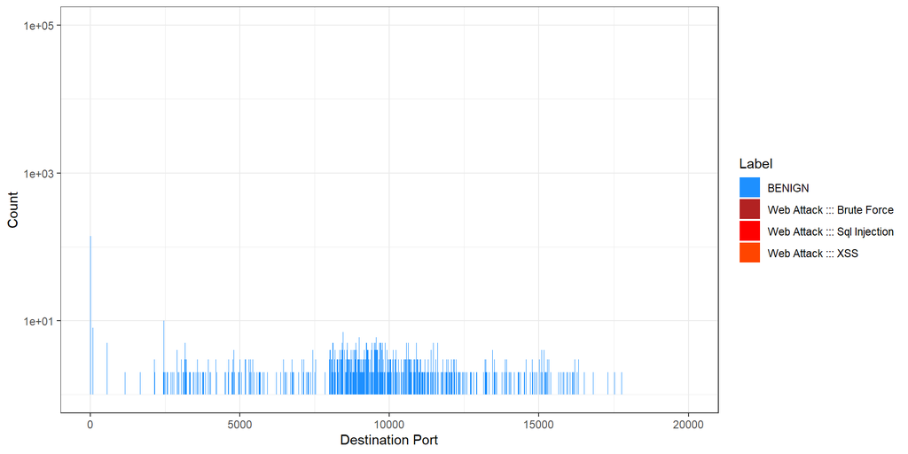

#### Binary Features

These features are predominantly flags set in the TCP/UDP packets (bidirectionally) for communication control. TCP/UDP flags can be useful in detecting malicious/anomalous communication when examining host to host exchanges but across the whole network they will often be drowned out.

Here’s a breakdown of the frequency with which each flag occurs per class $P(flag\ |\ class)$:

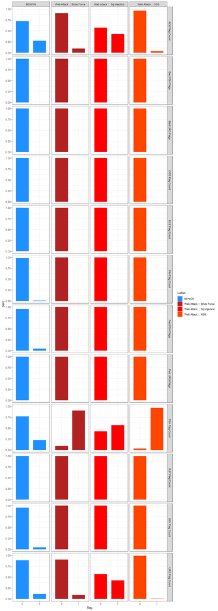

We can see that many of the boolean flags do appear more prevalent in certain cases, but let’s consider how useful that information may be by examining the reversed conditional probability: the probability of an packet transfer being in a certain class given that a flag was present $P(class\ |\ flag)$.

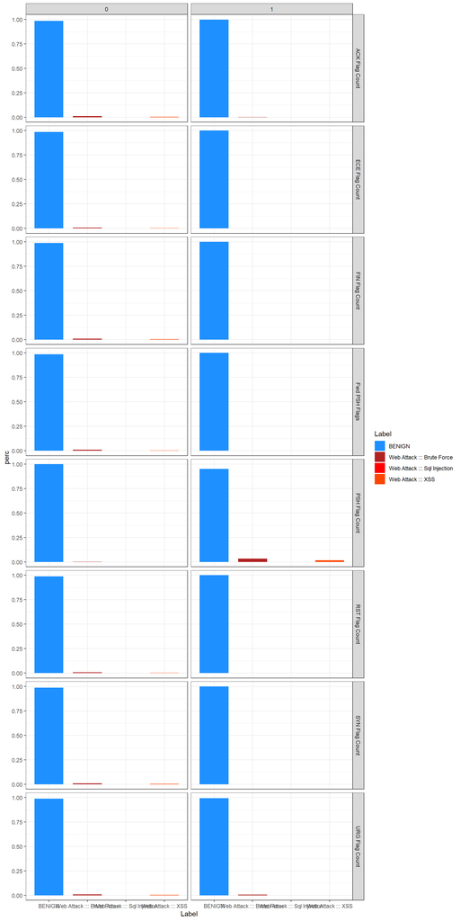

As such, the binary flags don’t seem to yield too much predictive power on their own. Though they would likely be invaluable for discerning different types of attacks, especially when we factor in a greater variety of attacks, it’s unclear how much utility they’ll bring for statistical outlier detection methods (given that the attacks blend into the general noise of regular traffic.)

#### Continuous Features

The continuous features of the data set are mostly derived from aspects of the packet size, duration, and distributions within each set of communications. Below is a histogram/density estimation for each of the features colored by label. *Notice that counts are again displayed on logarithmic scale to address the Pareto-like distributions.*

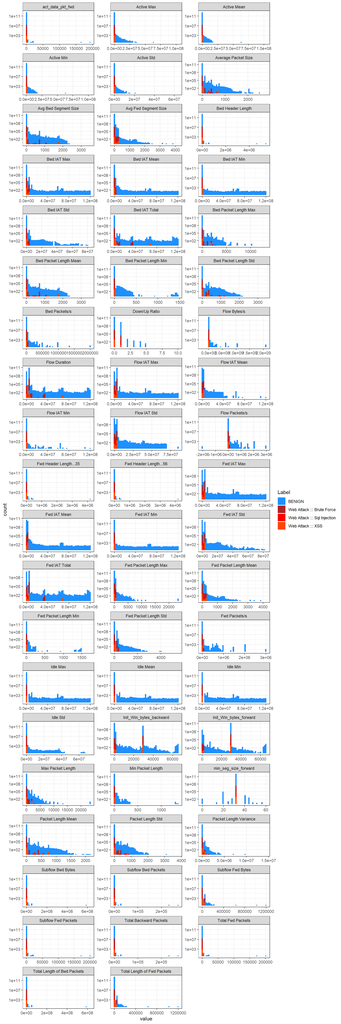

By and large, the malicious communications do not represent statistical outliers for these datasets. Presumably due to deliberate obfuscation, most attacks resemble the norm and do not land on the far end of the spectrum for any these features.

```
## Importance of components:
##                          PC1    PC2    PC3     PC4     PC5     PC6     PC7
## Standard deviation     3.747 3.3944 2.9019 1.86995 1.67666 1.61869 1.48700
## Proportion of Variance 0.238 0.1953 0.1427 0.05927 0.04765 0.04441 0.03748
## Cumulative Proportion  0.238 0.4333 0.5760 0.63529 0.68294 0.72735 0.76483
##                            PC8     PC9    PC10    PC11    PC12    PC13   PC14
## Standard deviation     1.40619 1.19096 1.14146 1.05277 1.03026 0.99895 0.9777
## Proportion of Variance 0.03351 0.02404 0.02208 0.01879 0.01799 0.01691 0.0162
## Cumulative Proportion  0.79834 0.82238 0.84447 0.86325 0.88124 0.89816 0.9144
##                           PC15    PC16   PC17    PC18    PC19    PC20    PC21
## Standard deviation     0.92588 0.86133 0.8164 0.70311 0.68675 0.56911 0.49673
## Proportion of Variance 0.01453 0.01257 0.0113 0.00838 0.00799 0.00549 0.00418
## Cumulative Proportion  0.92889 0.94146 0.9528 0.96114 0.96913 0.97462 0.97880
##                           PC22    PC23    PC24    PC25    PC26    PC27    PC28
## Standard deviation     0.47930 0.46568 0.41734 0.38028 0.35465 0.29428 0.23591
## Proportion of Variance 0.00389 0.00368 0.00295 0.00245 0.00213 0.00147 0.00094
## Cumulative Proportion  0.98270 0.98637 0.98932 0.99178 0.99391 0.99538 0.99632
##                           PC29    PC30    PC31    PC32    PC33    PC34    PC35
## Standard deviation     0.21806 0.20949 0.17629 0.13869 0.12754 0.11809 0.10039
## Proportion of Variance 0.00081 0.00074 0.00053 0.00033 0.00028 0.00024 0.00017
## Cumulative Proportion  0.99712 0.99787 0.99839 0.99872 0.99900 0.99923 0.99940
##                           PC36    PC37    PC38    PC39    PC40    PC41    PC42
## Standard deviation     0.09706 0.08103 0.06221 0.05179 0.05069 0.05025 0.04682
## Proportion of Variance 0.00016 0.00011 0.00007 0.00005 0.00004 0.00004 0.00004
## Cumulative Proportion  0.99956 0.99967 0.99974 0.99979 0.99983 0.99987 0.99991
##                           PC43    PC44    PC45    PC46    PC47    PC48    PC49
## Standard deviation     0.04133 0.03683 0.02345 0.02200 0.02128 0.01890 0.01498
## Proportion of Variance 0.00003 0.00002 0.00001 0.00001 0.00001 0.00001 0.00000
## Cumulative Proportion  0.99994 0.99996 0.99997 0.99998 0.99999 0.99999 1.00000
##                           PC50     PC51     PC52      PC53      PC54     PC55
## Standard deviation     0.01409 0.003783 0.002776 0.0004071 8.823e-12 2.58e-13
## Proportion of Variance 0.00000 0.000000 0.000000 0.0000000 0.000e+00 0.00e+00
## Cumulative Proportion  1.00000 1.000000 1.000000 1.0000000 1.000e+00 1.00e+00
##                             PC56      PC57      PC58      PC59
## Standard deviation     5.752e-15 5.072e-15 2.263e-15 8.106e-16
## Proportion of Variance 0.000e+00 0.000e+00 0.000e+00 0.000e+00
## Cumulative Proportion  1.000e+00 1.000e+00 1.000e+00 1.000e+00
```